# Tugas2_MPDW

2024-08-28

## **LIBRARY**

```r
library(dplyr)
library(TTR)
library(forecast)
library(lmtest) #digunakan untuk uji formal pendeteksian autokorelasi
library(orcutt) #untuk membuat model regresi Cochrane-Orcutt
library(HoRM) #untuk membuat model regresi Hildreth-Lu
library(readxl)
```

## **DATA**

Data yang digunakan adalah data GDP negara Pakistan sejak tahun 1960-2023

```r
data <- read_excel("/Users/fauzanfajari/Desktop/Kuliah/V/MPDW/Data-Tugas2_MPDW.xls", sheet = "GDP")
data <- as.data.frame(data)
```

```r
datats<-ts(data$GDP)
datats
```

```
## Time Series:
## Start = 1
## End = 64
## Frequency = 1
##  [1]   3749265015   4118647627   4310163797   4630827383   5204955901
##  [6]   5929231415   6561108778   7464510710   8041999160   8683116338
## [11]  10027509450  10665896682   9415016360   6383429490   8899191919
## [16]  11230606061  13168080808  15126060606  17811515152  19688383838
## [21]  23654444444  28100606061  30725971564  28691889764  31151825467
## [26]  31144920844  31899070056  33351529275  38472742808  40171106279
## [31]  40010423970  45625336680  48884671947  51809999353  52293470813
## [36]  60636071684  63320170084  62433340468  62191955814  62973857069
## [41]  99484802345  97145618480  97923302809 112371913741 132216048339
## [46] 145208562961 161871385506 184140869997 202203748584 187337783856
## [51] 196709621850 230586581060 250106966105 258657231672 271390474858
## [56] 299963590535 313630000130 339205534861 356128166705 320909472771
## [61] 300425609818 348516647445 374787958882 338368455318
```

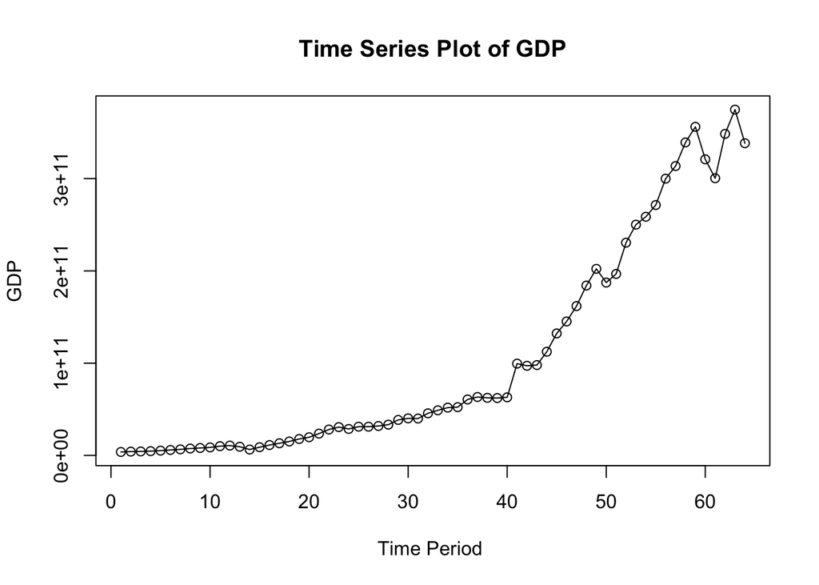

```r
ts.plot(datats, xlab="Time Period ", ylab="GDP", main= "Time Series Plot of GDP")
points(datats)
```

Untuk mempermudah pembentukan model, data yang digunakan adalah 59 data pertama atau periode 1960-2018 dengan *trend* yang cenderung naik.

# Eksplorasi Data

Sebelum melakukan regresi, akan diperlihatkan *plot time-series* dari GDP Negara Pakistan Periode 1960-2018

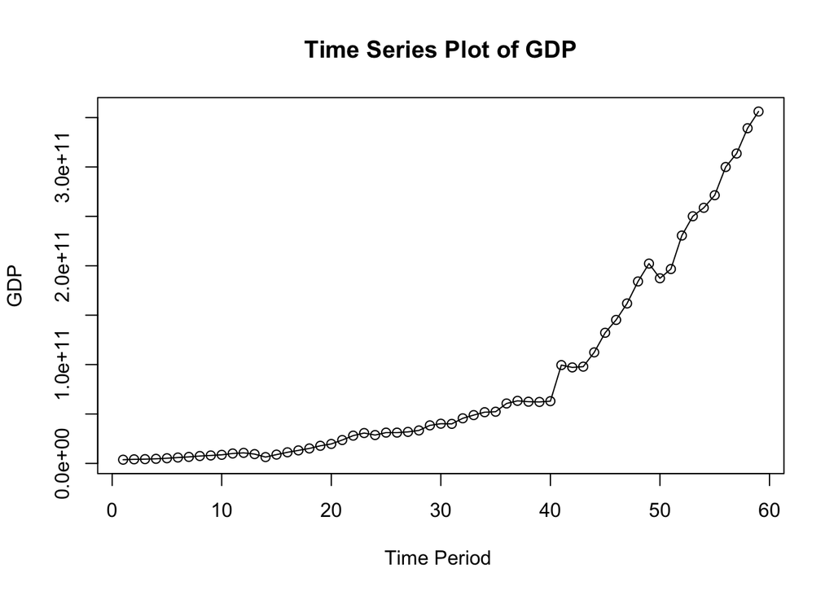

```r
#Ambil 59 data pertama
data1 <- data[1:59,]
dt.ts <- ts(data1$GDP)
ts.plot(dt.ts, xlab="Time Period ", ylab="GDP", main= "Time Series Plot of GDP")
points(dt.ts)
```

Selanjutnya akan dilakukan ramalan dan pemulusan dengan metode DMA dan DES karena terlihat pada plot di atas menunjukkan adanya *trend*.

```r
dt.sma <- SMA(dt.ts, n=4)
dma <- SMA(dt.sma, n = 4)
At <- 2*dt.sma - dma
Bt <- 2/(3-1)*(dt.sma - dma)
dt.dma<- At+Bt
dt.ramal<- c(NA, dt.dma)

t = 1:5
f = c()

for (i in t) {
  f[i] = At[length(At)] + Bt[length(Bt)]*(i)
}
```

```r
dt.gab <- cbind(aktual = c(dt.ts,rep(NA,5)),
                pemulusan1 = c(dt.sma,rep(NA,5)),
                pemulusan2 = c(dt.dma, rep(NA,5)),
                At = c(At, rep(NA,5)),
                Bt = c(Bt,rep(NA,5)),
                ramalan = c(dt.ramal, f[-1]))
dt.gab
```

```
##             aktual   pemulusan1   pemulusan2           At          Bt
##  [1,]   3749265015           NA           NA           NA          NA
##  [2,]   4118647627           NA           NA           NA          NA
##  [3,]   4310163797           NA           NA           NA          NA
##  [4,]   4630827383   4202225955           NA           NA          NA
##  [5,]   5204955901   4566148677           NA           NA          NA
##  [6,]   5929231415   5018794624           NA           NA          NA
##  [7,]   6561108778   5581530869   7060242545   6320886707   739355838
##  [8,]   7464510710   6289951701   8141642167   7215796934   925845233
##  [9,]   8041999160   6999212516   9052892692   8026052604  1026840088
## [10,]   8683116338   7687683746   9783861823   8735772785  1048089038
## [11,]  10027509450   8554283914  10897285804   9725784859  1171500945
## [12,]  10665896682   9354630407  11765985930  10560308169  1205677761
## [13,]   9415016360   9697884707  11446412734  10572148721   874264013
## [14,]   6383429490   9122962995   9004007974   9063485485   -59477511
```

[output cut: 115 more lines]

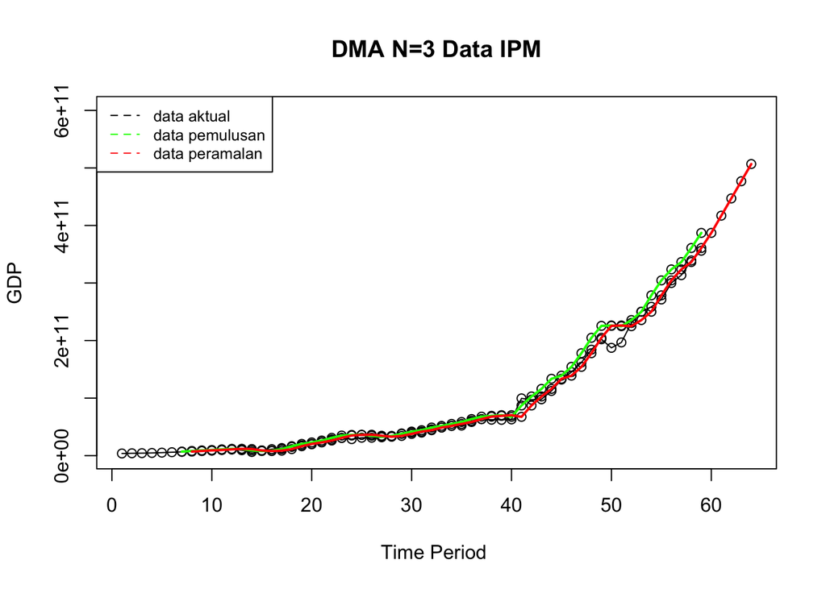

```r
#Plot time series
ts.plot(dt.gab[,1], xlab="Time Period ", ylab="GDP",
        main= "DMA N=3 Data IPM", ylim=c(1000000000,600000000000))
points(dt.gab[,1])
points(dt.gab[,3])
points(dt.gab[,6])
lines(dt.gab[,3],col="green",lwd=2)
lines(dt.gab[,6],col="red",lwd=2)
legend("topleft",c("data aktual","data pemulusan","data peramalan"),
       lty=8, col=c("black","green","red"), cex=0.8)
```

Selanjutnya akan dilihat keakuratan dari metode DMA

```r
#Menghitung Nilai Keakuratan
error.dma = dt.ts-dt.ramal[1:length(dt.ts)]
SSE.dma = sum(error.dma[8:length(dt.ts)]^2)
MSE.dma = mean(error.dma[8:length(dt.ts)]^2)
MAPE.dma = mean(abs((error.dma[8:length(dt.ts)]/dt.ts[8:length(dt.ts)])*100))

akurasi.dma <- matrix(c(SSE.dma, MSE.dma, MAPE.dma))
row.names(akurasi.dma)<- c("SSE", "MSE", "MAPE")
colnames(akurasi.dma) <- c("Akurasi m = 3")
akurasi.dma
```

```
##      Akurasi m = 3
## SSE   4.501456e+21
## MSE   8.656646e+19
## MAPE  9.257820e+00
```

Selanjutnya akan digunakan metode *Double Exponential Smoothing* dengan cara sebagai berikut.

Pertama akan data akan dibagi menjadi data *training* dan data *testing*.

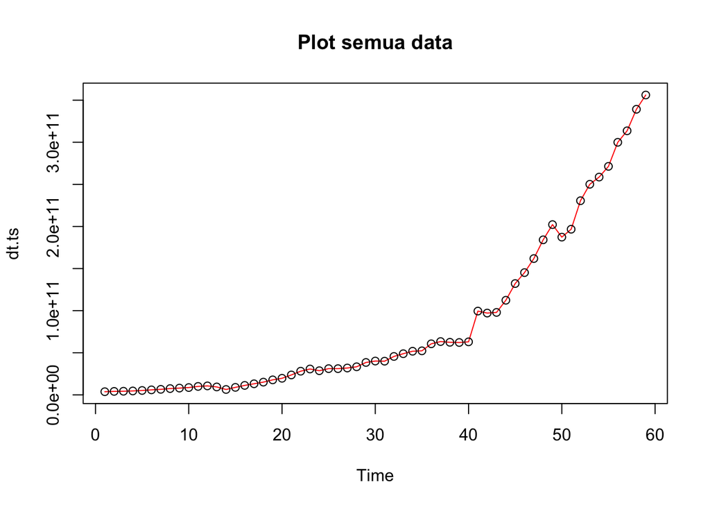

```r
#membagi training dan testing
training<-data1[1:48,2]
testing<-data1[49:59,2]

#data time series
training.ts<-ts(training)
testing.ts<-ts(testing,start=49)

#eksplorasi data
plot(dt.ts, col="red",main="Plot semua data")
points(dt.ts)
```

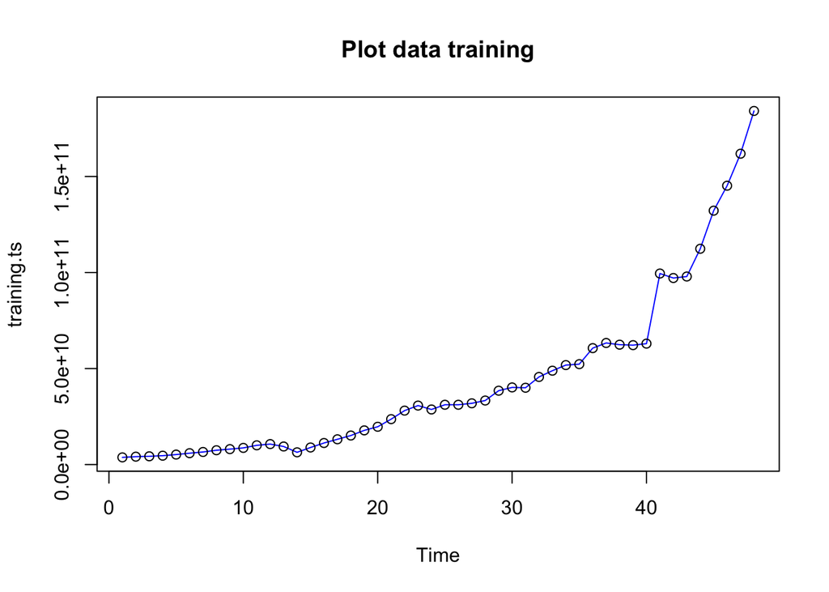

```r
plot(training.ts, col="blue",main="Plot data training")
points(training.ts)
```

Selanjutnya akan dilakukan pemulusan dengan DES, kali ini langsung dicari lambda dan gamma optimum sebagai berikut. Nilai lambda dan gamma optimum dapat dilihat pada smoothing parameters alpha untuk nilai lambda dan beta untuk nilai gamma.

```r
#Lamda dan gamma optimum
des.opt<- HoltWinters(training.ts, gamma = FALSE)
des.opt
```

```
## Holt-Winters exponential smoothing with trend and without seasonal component.
##
## Call:
## HoltWinters(x = training.ts, gamma = FALSE)
##
## Smoothing parameters:
##  alpha: 0.3938765
##  beta : 0.7470844
##  gamma: FALSE
##
## Coefficients:
##           [,1]
## a 178649191976
## b  18981194529
```

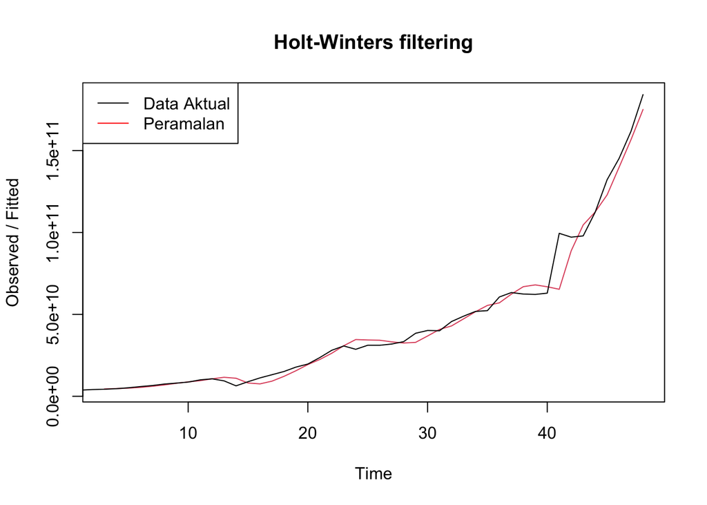

```r
plot(des.opt)
legend("topleft", c("Data Aktual", "Peramalan"), col = c("black", "red"),
       lty = c(1,1))
```

```r
#ramalan
ramalandesopt<- forecast(des.opt, h=11)
ramalandesopt
```

```
##    Point Forecast        Lo 80        Hi 80        Lo 95        Hi 95
## 49   197630386505 189764638638 205496134372 185600763238 209660009772
## 50   216611581034 207063423854 226159738215 202008934762 231214227307
## 51   235592775564 223309537087 247876014040 216807183415 254378367712
## 52   254573970093 238708398796 270439541391 230309672680 278838267507
## 53   273555164623 253445541101 293664788145 242800149448 304310179797
## 54   292536359152 267643906449 317428811855 254466637967 330606080337
## 55   311517553681 281382150581 341652956782 265429431811 357605675552
## 56   330498748211 294712768403 366284728018 275768815011 385228681411
## 57   349479942740 307672884350 391287001130 285541564491 413418320990
## 58   368461137270 320290209330 416632065210 294790060426 442132214113
## 59   387442331799 332586381437 442298282162 303547395427 471337268171
```

Selanjutnya akan dicari akurasi dari metode DES

```r
ssedes.train<-des.opt$SSE
msedes.train<-ssedes.train/length(training.ts)
sisaandes<-ramalandesopt$residuals
head(sisaandes)
```

```
## Time Series:
## Start = 1
## End = 6
## Frequency = 1
## [1]         NA         NA -177866443 -104189274  224591749  507932535
```

```r
mapedes.train <- sum(abs(sisaandes[3:length(training.ts)]/training.ts[3:length(training.ts)])*100)/length(training.ts)

akurasides.opt <- matrix(c(ssedes.train,msedes.train,mapedes.train))
row.names(akurasides.opt)<- c("SSE", "MSE", "MAPE")
colnames(akurasides.opt) <- c("Akurasi lamda dan gamma optimum")
akurasides.opt
```

```
##      Akurasi lamda dan gamma optimum
## SSE                     1.782166e+21
## MSE                     3.712846e+19
## MAPE                    9.169677e+00
```

```r
#Akurasi data testing
selisihdesopt<-ramalandesopt$mean-testing.ts
selisihdesopt
```

```
## Time Series:
## Start = 49
## End = 59
## Frequency = 1
##  [1] -4573362079 29273797178 38883153714 23987389034 23448198518 33879127480
##  [7] 40127078824 30535157676 35849942610 29255602409 31314165094
```

```r
SSEtestingdesopt<-sum(selisihdesopt^2)
SSEtestingdesopt<-SSEtestingdesopt/length(testing.ts)
MAPEtestingdesopt<-sum(abs(selisihdesopt/testing.ts)*100)/length(testing.ts)

akurasiDesTesting <- matrix(c(SSEtestingdesopt,SSEtestingdesopt,MAPEtestingdesopt))
row.names(akurasiDesTesting)<- c("SSE", "MSE", "MAPE")
colnames(akurasiDesTesting) <- c("Akurasi lamda dan gamma optimum")
akurasiDesTesting
```

```
##      Akurasi lamda dan gamma optimum
## SSE                     9.388220e+20
## MSE                     9.388220e+20
## MAPE                    1.130405e+01
```

Setelah didapatkan nilai akurasi untuk metode DMA dan DES, selanjutnya akan dibandingkan keakuratan antar metode keduanya.

```r
cbind(akurasi.dma, akurasides.opt)
```

```
##      Akurasi m = 3 Akurasi lamda dan gamma optimum
## SSE   4.501456e+21                    1.782166e+21
## MSE   8.656646e+19                    3.712846e+19
## MAPE  9.257820e+00                    9.169677e+00
```

Berdasarkan perbandingan akurasi tersebut, terlihat nilai SSE, MSE, dan MAPE metode DES lebih kecil dibandingkan dengan metode DMA. Oleh karena itu, metode peramalan dan pemulusan yang terbaik antara keduanya adalah dengan metode DES.

Setelah melakukan peramalan, data yang telah dimasukkan kemudian dieksplorasi. Eksplorasi pertama yang dilakukan adalah dengan menggunakan *scatter plot*.

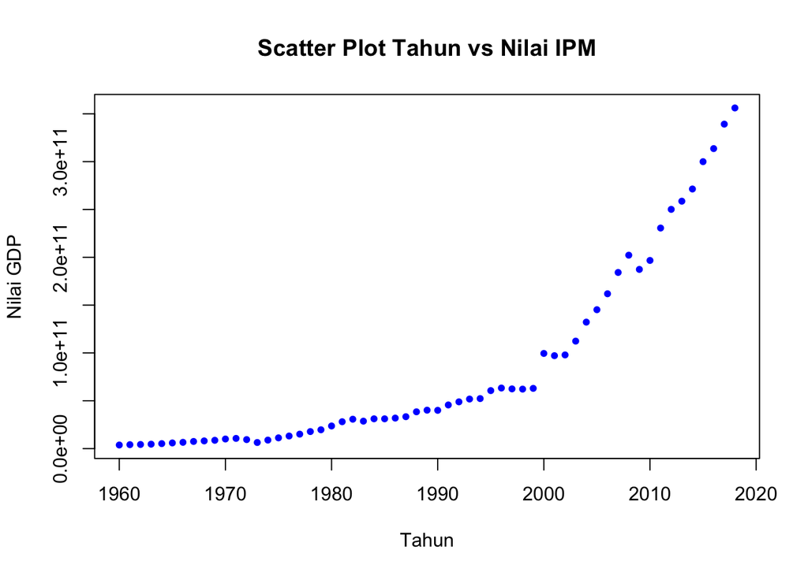

```r
#Eksplorasi Data
#Pembuatan Scatter Plot
plot(data1$Periode,data1$GDP, pch = 20, col = "blue",
     main = "Scatter Plot Tahun vs Nilai IPM",
     xlab = "Tahun",
     ylab = "Nilai GDP")
```

```r
#Menampilkan Nilai Korelasi
cor(data1$Periode,data1$GDP)
```

```
## [1] 0.8756139
```

Setalah mengetahui adanya hubungan antar dua peubah, maka model regresi dapat ditentukan.

## Regresi

```r
model<- lm(GDP~Periode, data = data1)
summary(model)
```

```
##
## Call:
## lm(formula = GDP ~ Periode, data = data1)
##
## Residuals:
##        Min         1Q     Median         3Q        Max
## -7.176e+10 -4.104e+10 -8.040e+09  3.454e+10  1.259e+11
##
## Coefficients:
##               Estimate Std. Error t value Pr(>|t|)
## (Intercept) -9.910e+12  7.303e+11  -13.57   <2e-16 ***
## Periode      5.025e+09  3.671e+08   13.69   <2e-16 ***
## ---
## Signif. codes:  0 '***' 0.001 '**' 0.01 '*' 0.05 '.' 0.1 ' ' 1
##
## Residual standard error: 4.802e+10 on 57 degrees of freedom
## Multiple R-squared:  0.7667, Adjusted R-squared:  0.7626
## F-statistic: 187.3 on 1 and 57 DF,  p-value: < 2.2e-16
```

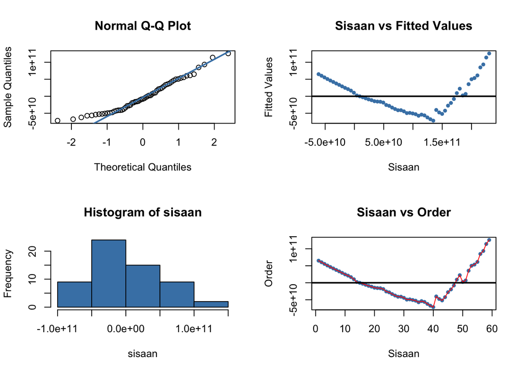

```r
#sisaan dan fitted value
sisaan <- residuals(model)
fitValue <- predict(model)

#Diagnostik dengan eksploratif
par(mfrow = c(2,2))
qqnorm(sisaan)
qqline(sisaan, col = "steelblue", lwd = 2)
plot(fitValue, sisaan, col = "steelblue", pch = 20, xlab = "Sisaan", ylab = "Fitted Values", main = "Sisaan vs Fitted Values")
abline(a = 0, b = 0, lwd = 2)
hist(sisaan, col = "steelblue")
plot(seq(1,59,1), sisaan, col = "steelblue", pch = 20, xlab = "Sisaan", ylab = "Order", main = "Sisaan vs Order")
lines(seq(1,59,1), sisaan, col = "red")
abline(a = 0, b = 0, lwd = 2)
```

Dua plot di samping kiri digunakan untuk melihat apakah sisaan menyebar normal. Normal Q-Q Plot di atas menunjukkan bahwa sisaan cenderung menyebar normal, tetapi histogram dari sisaan tidak menunjukkan demikian. Selanjutnya, dua plot di samping kanan digunakan untuk melihat autokorelasi. Plot Sisaan vs Fitted Value dan Plot Sisaan vs Order menunjukkan adanya pola pada sisaan. Untuk lebih lanjut akan digunakan uji formal melihat normalitas sisaan dan plot ACF dan PACF untuk melihat apakah ada autokorelasi atau tidak.

```r
#Melihat Sisaan Menyebar Normal/Tidak
#H0: sisaan mengikuti sebaran normal
#H1: sisaan tidak mengikuti sebaran normal
shapiro.test(sisaan)
```

```
##
##  Shapiro-Wilk normality test
##
## data:  sisaan
## W = 0.95123, p-value = 0.0192
```

```r
ks.test(sisaan, "pnorm", mean=mean(sisaan), sd=sd(sisaan))
```

```
##
##  Exact one-sample Kolmogorov-Smirnov test
##
## data:  sisaan
## D = 0.089752, p-value = 0.695
## alternative hypothesis: two-sided
```

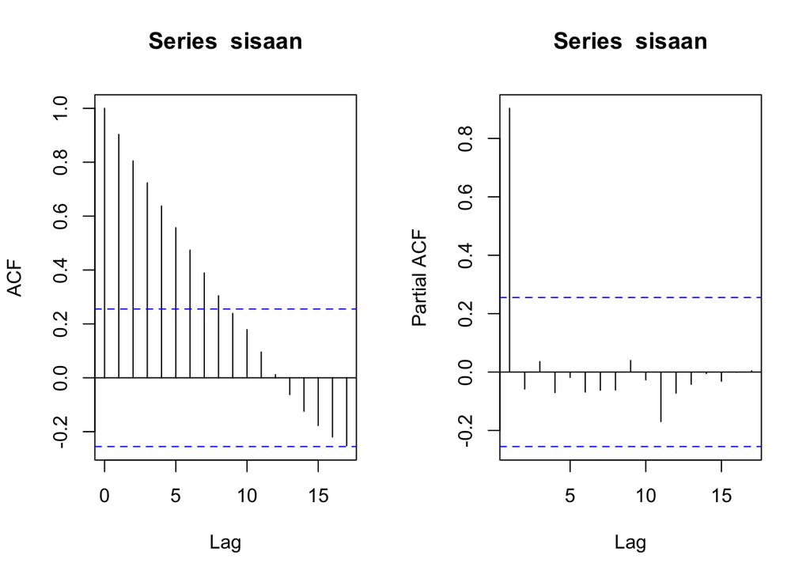

```r
#ACF dan PACF identifikasi autokorelasi
par(mfrow = c(1,2))
acf(sisaan)
pacf(sisaan)
```

```r
#Deteksi autokorelasi dengan uji-Durbin Watson
#H0: tidak ada autokorelasi
#H1: ada autokorelasi
dwtest(model)
```

```
##
##  Durbin-Watson test
##
## data:  model
## DW = 0.041153, p-value < 2.2e-16
## alternative hypothesis: true autocorrelation is greater than 0
```

Berdasarkan hasil DW Test, didapatkan nilai $DW = 0.041153$ dan p-value = $2.2e-16$. Namun, dengan nilai p-value < 0.05 dapat disimpulkan bahwa tolak H0, cukup bukti mengatakan adanya autokorelasi. Oleh karena itu, diperlukan penangan autokorelasi. Penanganan yang akan digunakan menggunakan dua metode, yaitu Cochrane-Orcutt dan Hildret-Lu.

## Penanganan Autokorelasi

### Metode Cochrane-Orcutt

Penanganan metode Cochrane-Orcutt dapat dilakukan dengan bantuan packages Orcutt pada aplikasi R maupun secara manual. Berikut ini ditampilkan cara menggunakan bantuan library packages Orcutt.

```r
modelCO<-cochrane.orcutt(model, max.iter = 1000)
modelCO
```

```
## Cochrane-orcutt estimation for first order autocorrelation
##
## Call:
## lm(formula = GDP ~ Periode, data = data1)
##
##  number of interaction: 535
##  rho 1.039582
##
## Durbin-Watson statistic
## (original):    0.04115 , p-value: 3.949e-47
## (transformed): 2.16835 , p-value: 6.942e-01
##
##  coefficients:
##   (Intercept)       Periode
## 7693898829872   -3956519278
```

Hasil keluaran model setelah dilakukan penanganan adalah sebagai berikut.
$$y_i=7693898829872-3956519278x_t$$
Hasil juga menunjukkan bahwa nilai DW dan p-value meningkat menjadi $2.16835$ dan $0.6942$. Hal tersebut juga didukung dengan nilai *p-value* > 0.05, artinya belum cukup bukti menyatakan bahwa sisaan terdapat autokorelasi pada taraf nyata 5%. Untuk nilai $ρ ̂$ optimum yang digunakan adalah $1.039582$. Nilai tersebut dapat diketahui dengan *syntax* berikut.

```r
rho<- modelCO$rho
rho
```

```
## [1] 1.039582
```

Selanjutnya akan dilakukan transformasi secara manual dengan syntax berikut ini.

```r
data1$GDP
```

```
##  [1]   3749265015   4118647627   4310163797   4630827383   5204955901
##  [6]   5929231415   6561108778   7464510710   8041999160   8683116338
## [11]  10027509450  10665896682   9415016360   6383429490   8899191919
## [16]  11230606061  13168080808  15126060606  17811515152  19688383838
## [21]  23654444444  28100606061  30725971564  28691889764  31151825467
## [26]  31144920844  31899070056  33351529275  38472742808  40171106279
## [31]  40010423970  45625336680  48884671947  51809999353  52293470813
## [36]  60636071684  63320170084  62433340468  62191955814  62973857069
## [41]  99484802345  97145618480  97923302809 112371913741 132216048339
## [46] 145208562961 161871385506 184140869997 202203748584 187337783856
## [51] 196709621850 230586581060 250106966105 258657231672 271390474858
## [56] 299963590535 313630000130 339205534861 356128166705
```

```r
data1$GDP[-1]
```

```
##  [1]   4118647627   4310163797   4630827383   5204955901   5929231415
##  [6]   6561108778   7464510710   8041999160   8683116338  10027509450
## [11]  10665896682   9415016360   6383429490   8899191919  11230606061
## [16]  13168080808  15126060606  17811515152  19688383838  23654444444
## [21]  28100606061  30725971564  28691889764  31151825467  31144920844
## [26]  31899070056  33351529275  38472742808  40171106279  40010423970
## [31]  45625336680  48884671947  51809999353  52293470813  60636071684
## [36]  63320170084  62433340468  62191955814  62973857069  99484802345
## [41]  97145618480  97923302809 112371913741 132216048339 145208562961
## [46] 161871385506 184140869997 202203748584 187337783856 196709621850
## [51] 230586581060 250106966105 258657231672 271390474858 299963590535
## [56] 313630000130 339205534861 356128166705
```

```r
#Transformasi Manual
gdp.trans<- data1$GDP[-1]-data1$GDP[-12]*rho
tahun.trans<- data1$Periode[-1]-data1$Periode[-12]*rho
modelCOmanual<- lm(gdp.trans~tahun.trans)
summary(modelCOmanual)
```

```
##
## Call:
## lm(formula = gdp.trans ~ tahun.trans)
##
## Residuals:
##        Min         1Q     Median         3Q        Max
## -6.609e+09 -1.812e+09  1.416e+09  2.072e+09  2.605e+09
##
## Coefficients:
##              Estimate Std. Error t value Pr(>|t|)
## (Intercept) 2.464e+11  2.624e+10   9.389 4.26e-13 ***
## tahun.trans 3.178e+09  3.341e+08   9.515 2.69e-13 ***
## ---
## Signif. codes:  0 '***' 0.001 '**' 0.01 '*' 0.05 '.' 0.1 ' ' 1
##
## Residual standard error: 2.508e+09 on 56 degrees of freedom
## Multiple R-squared:  0.6178, Adjusted R-squared:  0.611
## F-statistic: 90.53 on 1 and 56 DF,  p-value: 2.686e-13
```

```r
#Mencari Penduga Koefisien Regresi setelah Transformasi ke Persamaan Awal
b0bintang <- modelCOmanual$coefficients[-2]
b0 <- b0bintang/(1-rho)
b1 <- modelCOmanual$coefficients[-1]
b0
```

```
##   (Intercept)
## -6.224952e+12
```

```r
b1
```

```
## tahun.trans
##  3178454233
```